# Tech-Report for Michael Stein’s Flexible Behavior in Both Tails Model

2023-08-09

# Introduction

We will go through our results and two problems we encounter when we compute the era-adjusted bWAR using the [Michael Stein’s model](https://onlinelibrary.wiley.com/doi/abs/10.1002/env.2658). Since the source code writen by Chris Geoga for Michael Stein’s lexible behavior in both tails model is employed in the Julia environment, we will display our results from Julia environment.

# Results

When we compute the era-adjusted bWAR using the Michael Stein’s model, we see our findings are not consistent with the basic baseball knowledge. For example, Willie Stargell in 1971 has larger bWAR talents scores than Mookie Betts in 2018 from our results. This does not make sense because Mookie Betts in 2018 has higher bWAR with larger talent pool than Willie Stargell in 1971. Also Mookie Betts in 2018 stands farther away from his peers than Willie Stargell in 1971. The table below shows the data from our findings using the Michael Stein’s model. ‘dis_2nd’ shows the difference between the player to the second best batters in bWAR. ‘dis_3rd’ shows the difference between the player to the third best batters in bWAR. We have spotted similar problems in this dataset when using Michael Stein’s model.

| name | year | bWAR | pops | dis_2nd | dis_3rd | talent |
| --- | --- | --- | --- | --- | --- | --- |
| Willie Stargell | 1971 | 7.92 | 8.3e+06 | 0.4 | 0.6 | 3260000 |
| Mookie Betts | 2018 | 10.68 | 1.6e+07 | 0.8 | 2.8 | 3210000 |

# Restoration Problem

We select full-time pitchers’ bWAR in 1874 as the component in our Full House Model system. When we attempt to find the Maximum Likelihood Estimator(MLE) using the function ‘fitstein_ipopt_robust’ from the ‘steinmodel.jl’, the Julia displays the following problem:

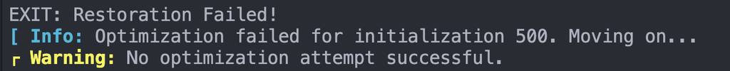

Figure 1: Restoration

We set the initialization number is 500 and maximum number of iteration is 1000.

# Optimation Problem

We use the same dataset in the last problem and we increase the initialization number to 1000. Then we get the following problem:

[figure not shown]

Figure 2: Restoration

# Appendix

Here is the Julia code we use to compute the MLE.

```julia
using CSV
using DelimitedFiles
using DataFrames
using Distributions
using JLD
using StatsBase

cd("/Users/yanshen/Desktop/PhD_UIUC/ProfEck/baseball/pitching/stein/steinextremes")

include("steinmodel.jl")

batters = DataFrame(CSV.read("batters_combined_b.csv"))

function Ftilde(y)
    (status, mle, mle_hessian) = fitstein_ipopt_robust(y, 500, INIT_TDIST_V2, maxit=1000)
    fitted_quants = map(z->steincdf(z, mle), y)
    return fitted_quants
end

function order_pbino(p, k, n)
    b = Binomial(n, p)
    return sum(pdf.(b, collect(k:n)))
end

function order_bino_vec(p)
    p  = sort!(p)
    n = length(p)
    res = zeros(n)
    for i = 1:n
        res[i] = order_pbino(p[i], i, n)
    end
    return res
end

function order_Pareto_vec(u, alpha, npop)
    n = length(u)
    if length(npop) == 1
        npop = fill(npop,n)
    end
    res = zeros(n)
    for i = 1:n
        res[i] = quantile.(Pareto(alpha), quantile.(Beta(i + npop[i] - n, n+1-i), u[i]))
    end
    return res
end

function map_Pareto_vals_vec(x, alpha, npop)
    n = length(x)
    if length(npop) == 1
        npop = fill(npop,n)
    end
    res = zeros(n)
    for i = 1:n
        res[i] = cdf(Beta(i + npop[i] - n, n+1-i), cdf(Pareto(alpha), x[i]))
    end
    return res
end

function order_qempirical(u, y)
    n = length(u)
    q = zeros(n)
    for i = 1:n
        q[i] = quantile.(Beta(i, n+1-i), u[i])
    end
    (status, mle, mle_hessian) = fitstein_ipopt_robust(y, 200, INIT_TDIST_V2, maxit=1000)
    return last.(map(z->steinquantile(z,mle), q))
end

foo = sort!(filter(:yearID => yearID -> yearID == 1967, batters), :WAR)
m = filter(:PA => PA -> PA >= 75, foo)[:,"PA"]
thres = median(m)
y = filter(:PA => PA -> PA >= (thres-2), foo)
y_star  = filter(:PA => PA -> PA < thres, foo)
n = nrow(y)
n_star = nrow(y_star)
(status, mle, mle_hessian) = fitstein_ipopt_robust(y[:,"WAR"], 200, INIT_TDIST_V2, maxit=1000)
p = map(z->steincdf(z, mle), y[:,"WAR"])
p_star = map(z->steincdf(z, mle), y_star[:,"WAR"])
u = order_bino_vec(p)
WAR_talent = order_Pareto_vec(u, 1.16, y[:, "pops"])
WAR_leader_board = hcat(y, WAR_talent)
# calculate the war talent for non-full-time players

for i in 1:n_star
    p = map(z->steincdf(z, mle), y[:,"WAR"])
    p_star = map(z->steincdf(z, mle), y_star[:,"WAR"])
    new_p = sort!(push!(p, p_star[i]))
    pos = findall(x -> x == p_star[i],new_p)[1]
    pops = mean(y[:,"pops"])
    u = order_bino_vec(new_p)
    WAR_talent = order_Pareto_vec(u, 1.16, pops)[pos]
    WAR_talent = [WAR_talent]
    WAR_leader_board = vcat(WAR_leader_board, hcat(DataFrame(y_star[i,:]), WAR_talent))
end

WAR_batter_best = WAR_leader_board

for i in vcat(1871:1966, 1968:2019)
    foo = sort!(filter(:yearID => yearID -> yearID == i, batters), :WAR)
    m = filter(:PA => PA -> PA >= 75, foo)[:,"PA"]
    thres = median(m)
    y = filter(:PA => PA -> PA >= thres, foo)
    y_star  = filter(:PA => PA -> PA < thres, foo)
    n = nrow(y)
    n_star = nrow(y_star)
    (status, mle, mle_hessian) = fitstein_ipopt_robust(y[:,"WAR"], 200, INIT_TDIST_V2, maxit=1000)
    p = map(z->steincdf(z, mle), y[:,"WAR"])
    p_star = map(z->steincdf(z, mle), y_star[:,"WAR"])
    u = order_bino_vec(p)
    WAR_talent = order_Pareto_vec(u, 1.16, y[:, "pops"])
    WAR_leader_board = hcat(y, WAR_talent)
    # calculate the war talent for non-full-time players

    for j in 1:n_star
        p = map(z->steincdf(z, mle), y[:,"WAR"])
        p_star = map(z->steincdf(z, mle), y_star[:,"WAR"])
        new_p = sort!(push!(p, p_star[j]))
        pos = findall(x -> x == p_star[j],new_p)[1]
        pops = mean(y[:,"pops"])
        u = order_bino_vec(new_p)
        WAR_talent = order_Pareto_vec(u, 1.16, pops)[pos]
        WAR_talent = [WAR_talent]
        WAR_leader_board = vcat(WAR_leader_board, hcat(DataFrame(y_star[j,:]), WAR_talent))
    end

    WAR_batter_best = vcat(WAR_batter_best, WAR_leader_board)
end

WAR_batter_best = sort!(WAR_batter_best, :x1, rev = true)
print(WAR_batter_best[1:25,:])


pitchers = DataFrame(CSV.read("pitchers_combined_b.csv"))
foo = sort!(filter(:yearID => yearID -> yearID == 1874, pitchers), :WAR)
m = filter(:IPouts => IPouts -> IPouts >= 100, foo)[:,"IPouts"]
thres = median(m)
y = filter(:IPouts => IPouts -> IPouts >= (thres), foo)
n = nrow(y)
(status, mle, mle_hessian) = fitstein_ipopt_robust(y[:,"WAR"],500, INIT_TDIST_V2, maxit=1000)
(status, mle, mle_hessian) = fitstein_ipopt_robust(y[:,"WAR"],1000, INIT_TDIST_V2, maxit=1000)
```